# Practical Machine Learning: Prediction Assignment Writeup

Alex Cairns

November 9, 2016

## Introduction

This document outlines the steps I took to build and train my prediction model for the final assignment for *Practical Machine Learning.* The objective of the assignment is to use various measurements from accelerometers to predict which bicept curl the participant performed for a given repeatition.

## Data Preparation

After loading the training data, the first inspection of the data revealed that there were many variables missing data for many observations where the *new_window* was equal to yes. The study’s website did not provide a description of this variable, so only the observations where the *new_window* was equal to “no” were kept (see code below).

```r
#Load the data
setwd("C:/Users/acairns/Documents/GitHub/PracticalMachineLearning")
train.data <- read.csv(file = "pml-training.csv", header = TRUE)

#Eliminate observations where "New_window" equals yes
train.data <- train.data[train.data$new_window == "no",]

#Drop "descriptor"" columns
ColToDelete <- c("X", "user_name", "new_window", "raw_timestamp", "num_window", "cvtd_timestamp")
train.data <- train.data[, -grep(paste(ColToDelete, collapse = "|"), colnames(train.data))]

#Eliminate variables where all observations are NAs
NAObs <- apply(train.data, 2, function(i) sum(!is.na(i)) == nrow(train.data))
train.data <- train.data[,names(NAObs[NAObs == TRUE])]

#Eliminate variables with missing values
CompleteObs <- apply(train.data, 2, function(i) length(i[i == ""]) == 0)
train.data <- train.data[, names(CompleteObs[CompleteObs == TRUE])]

#Predictors being considered
colnames(train.data)
```

```
##  [1] "roll_belt"            "pitch_belt"           "yaw_belt"
##  [4] "total_accel_belt"     "gyros_belt_x"         "gyros_belt_y"
##  [7] "gyros_belt_z"         "accel_belt_x"         "accel_belt_y"
## [10] "accel_belt_z"         "magnet_belt_x"        "magnet_belt_y"
## [13] "magnet_belt_z"        "roll_arm"             "pitch_arm"
## [16] "yaw_arm"              "total_accel_arm"      "gyros_arm_x"
## [19] "gyros_arm_y"          "gyros_arm_z"          "accel_arm_x"
## [22] "accel_arm_y"          "accel_arm_z"          "magnet_arm_x"
## [25] "magnet_arm_y"         "magnet_arm_z"         "roll_dumbbell"
## [28] "pitch_dumbbell"       "yaw_dumbbell"         "total_accel_dumbbell"
## [31] "gyros_dumbbell_x"     "gyros_dumbbell_y"     "gyros_dumbbell_z"
## [34] "accel_dumbbell_x"     "accel_dumbbell_y"     "accel_dumbbell_z"
## [37] "magnet_dumbbell_x"    "magnet_dumbbell_y"    "magnet_dumbbell_z"
## [40] "roll_forearm"         "pitch_forearm"        "yaw_forearm"
## [43] "total_accel_forearm"  "gyros_forearm_x"      "gyros_forearm_y"
## [46] "gyros_forearm_z"      "accel_forearm_x"      "accel_forearm_y"
## [49] "accel_forearm_z"      "magnet_forearm_x"     "magnet_forearm_y"
## [52] "magnet_forearm_z"     "classe"
```

## Model Building

Given that the study attached accelerometers to different parts of the body to assess the movement, many of the measurements will likely be correlated due to the fact the participants had to move, say, their arm and dumbbell in a certain manner in order to perform the exercise a certain way. I use a random forest model to account for correlation between the various predictors, and because we are looking a classification problem here.

The next step was to identify the predictors to include in the model. To do this a random forest model was run using all 52 predictors. An additional benefit to using a random forest model is that it provides an natural way to perform cross-validation. Since random forest models bootstrap the training data set, observations in our original training set not included in the bootstrapped sample act in the same manner as a test data set. Thus, we can approximate the test set error by generating out-of-bag (OOB) (“test”) errors on those observations not included. Each predictor was then ranked in terms of their importance, where importance is defined as the average (over m trees) reduction in the Gini index (a measure of node purity) when the node uses a given variable.

The figure 1 below shows the results from the latter exercise (larger values indicate stronger predictors).

```r
set.seed(123)
fit.rf <- randomForest(classe ~ ., data = train.data, ntree = 500, mtry = 7, importance = T)
varimp <- importance(fit.rf, type = 2) #mean decrease in node purity
RankVarImp <- as.matrix(cbind(varimp[order(-varimp[,1]), ], Rank = 1:nrow(varimp)))
RankVarImp
```

```
##                                 Rank
## roll_belt            1194.00682    1
## yaw_belt              912.28825    2
## pitch_forearm         758.46973    3
## magnet_dumbbell_z     756.54032    4
## pitch_belt            680.07919    5
## magnet_dumbbell_y     654.53130    6
## roll_forearm          628.93573    7
## magnet_dumbbell_x     465.42463    8
## roll_dumbbell         415.22749    9
## accel_belt_z          392.95861   10
## accel_dumbbell_y      391.72774   11
## magnet_belt_y         382.63159   12
## magnet_belt_z         372.16451   13
## accel_dumbbell_z      336.54350   14
## accel_forearm_x       326.90508   15
## gyros_belt_z          312.03245   16
## roll_arm              308.13382   17
## magnet_forearm_z      288.84547   18
## accel_dumbbell_x      259.78798   19
## total_accel_dumbbell  259.30252   20
## yaw_arm               250.73721   21
## accel_arm_x           248.52425   22
## yaw_dumbbell          243.37722   23
## magnet_belt_x         237.06471   24
## magnet_arm_x          235.04784   25
## accel_forearm_z       234.51554   26
## gyros_dumbbell_y      226.40509   27
## magnet_forearm_y      221.73085   28
## total_accel_belt      220.71217   29
## magnet_arm_y          220.19267   30
## magnet_forearm_x      207.18160   31
## magnet_arm_z          179.41086   32
## pitch_dumbbell        173.82909   33
## pitch_arm             171.56448   34
## yaw_forearm           160.53403   35
## accel_arm_y           147.37601   36
## accel_forearm_y       136.28949   37
## gyros_arm_y           136.01234   38
## gyros_arm_x           131.80037   39
## accel_arm_z           130.82943   40
## gyros_dumbbell_x      122.16410   41
## gyros_belt_y          120.85996   42
## gyros_forearm_y       120.78651   43
## accel_belt_y          119.73137   44
## total_accel_forearm   112.86036   45
## accel_belt_x          112.09370   46
## total_accel_arm        95.22604   47
## gyros_belt_x           91.92862   48
## gyros_dumbbell_z       81.66835   49
## gyros_forearm_z        76.83709   50
## gyros_forearm_x        71.43232   51
## gyros_arm_z            54.28706   52
```

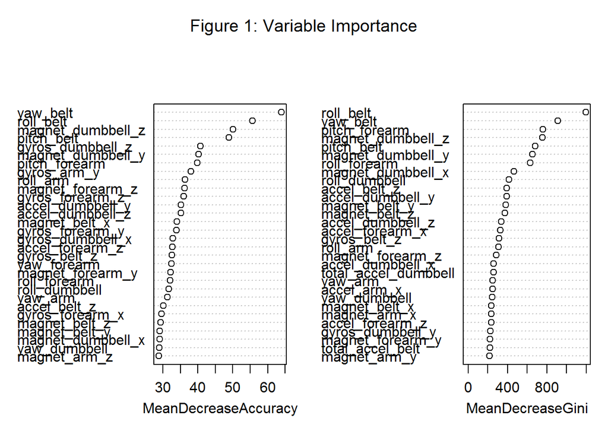

```r
### Plot
varImpPlot(fit.rf, main = "Figure 1: Variable Importance")
```

```r
### Loop Through various specifications
Iterations <- lapply(7:nrow(RankVarImp), function(i){
            varNames <- rownames(RankVarImp[1:i, ])
            set.seed(i)
            fit <- randomForest(train.data[,varNames], y = train.data$classe, ntree = 500, mtry = 7)
            k <- fit$confusion[,1:5]
            OOBestimate <- 1 - sum(diag(k))/sum(colSums(k))
            OOBestimate
      })

# Variable count with lowest OOB error
dat <- data.frame(NumofVar = 7:nrow(RankVarImp), OOBError = do.call(c, Iterations))
dat[dat$OOBError == min(dat$OOBError),]
```

```
##    NumofVar    OOBError
## 34       40 0.002654038
## 41       47 0.002654038
## 43       49 0.002654038
```

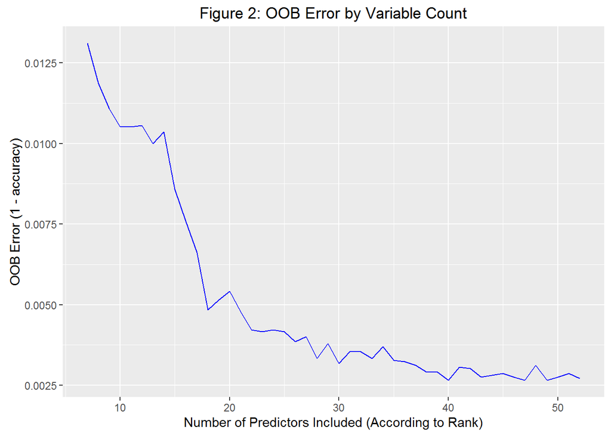

```r
# Generate Plot
g <- ggplot(data = dat, aes(x = NumofVar, y = OOBError)) + geom_line(col = "blue")
g <- g + ggtitle("Figure 2: OOB Error by Variable Count") + xlab("Number of Predictors Included (According to Rank)")
g + ylab("OOB Error (1 - accuracy)")
```

## Final Model

Below is the final model. The out of sample error is 0.27% as reported by printing *fit.rfFinal*. The code chunk below shows the predictions of the model given the test set.

```r
set.seed(12345)
fit.rfFinal <- randomForest(classe ~ roll_belt + yaw_belt + pitch_forearm + magnet_dumbbell_z + pitch_belt
                            + magnet_dumbbell_y + roll_forearm + magnet_dumbbell_x + roll_dumbbell + accel_dumbbell_y
                            + accel_belt_z + magnet_belt_y + magnet_belt_z + accel_forearm_x + accel_dumbbell_z
                            + roll_arm + gyros_belt_z + magnet_forearm_z + total_accel_dumbbell + yaw_dumbbell
                            + magnet_arm_x + yaw_arm + gyros_dumbbell_y + magnet_belt_x + accel_forearm_z
                            + accel_dumbbell_x + magnet_arm_y + magnet_forearm_y + magnet_forearm_x + accel_arm_x
                            + total_accel_belt + yaw_forearm + magnet_arm_z + pitch_arm + accel_arm_y
                            + accel_forearm_y + gyros_arm_y + gyros_arm_x + accel_arm_z + gyros_dumbbell_x
                            + gyros_forearm_y + gyros_belt_y + accel_belt_x + total_accel_forearm + total_accel_arm
                            + gyros_belt_x + gyros_dumbbell_z +  pitch_dumbbell + accel_belt_y
                            , data = train.data, ntree = 2500, mtry = 7, importance = T)

#Out of sample/OOB Error of Final Model
fit.rfFinal
```

```
##
## Call:
##  randomForest(formula = classe ~ roll_belt + yaw_belt + pitch_forearm +      magnet_dumbbell_z + pitch_belt + magnet_dumbbell_y + roll_forearm +      magnet_dumbbell_x + roll_dumbbell + accel_dumbbell_y + accel_belt_z +      magnet_belt_y + magnet_belt_z + accel_forearm_x + accel_dumbbell_z +    …
##                Type of random forest: classification
##                      Number of trees: 2500
## No. of variables tried at each split: 7
##
##         OOB estimate of  error rate: 0.27%
## Confusion matrix:
##      A    B    C    D    E  class.error
## A 5468    2    0    0    1 0.0005483458
## B    9 3706    3    0    0 0.0032275417
## C    0   10 3340    2    0 0.0035799523
## D    0    0   20 3125    2 0.0069907849
## E    0    0    0    3 3525 0.0008503401
```

```r
### Make Test Set Predictions
test.data <- read.csv(file = "pml-testing.csv", header = TRUE)
pred.val <- predict(fit.rfFinal, newdata = test.data)
pred.val
```

```
##  1  2  3  4  5  6  7  8  9 10 11 12 13 14 15 16 17 18 19 20
##  B  A  B  A  A  E  D  B  A  A  B  C  B  A  E  E  A  B  B  B
## Levels: A B C D E
```